# Homework 2

Author

Oscar Lam

## Question 1

```r
library(nycflights13)
library(dplyr)
library(tidyr)
library(ggplot2)

flights <- flights

top_dest <- flights %>%
  group_by(dest) %>%
  summarise(num_flights = n()) %>%
  arrange(desc(num_flights)) %>%
  head(10)

top_dest
```

```
# A tibble: 10 × 2
   dest  num_flights
   <chr>       <int>
 1 ORD         17283
 2 ATL         17215
 3 LAX         16174
 4 BOS         15508
 5 MCO         14082
 6 CLT         14064
 7 SFO         13331
 8 FLL         12055
 9 MIA         11728
10 DCA          9705
```

The above table shows the top 10 destinations and the number of flights to each of them.

## Question 2

```r
sum(is.na(flights$dep_time))
```

```
[1] 8255
```

```r
sum(is.na(flights$arr_time))
```

```
[1] 8713
```

Checked for NA in the data, proceed to filter those out for analysis

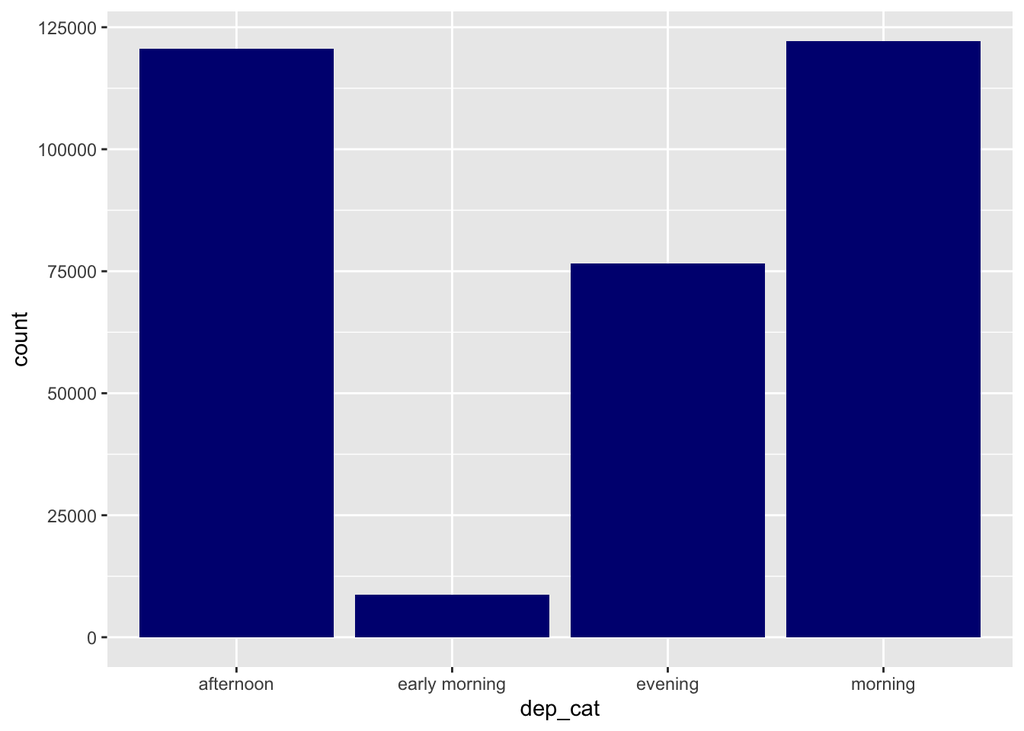

```r
flights <- flights %>%
  filter(!is.na(dep_time), !is.na(arr_time)) %>%
  mutate(
    #hours are currently in 515/2315, only wants to keep the hour
    dep_hour= floor(dep_time/100),
    arr_hour= floor(arr_time/100),

    dep_cat = case_when(
      dep_hour< 6  ~ "early morning",
      dep_hour< 12 ~ "morning",
      dep_hour< 18 ~ "afternoon",
      dep_hour<=24 ~ "evening"
    ),

    arr_cat= case_when(
      arr_hour< 6  ~ "early morning",
      arr_hour< 12 ~ "morning",
      arr_hour< 18 ~ "afternoon",
      arr_hour<=24 ~ "evening"
    )
  )

ggplot(flights, aes(dep_cat)) +
  geom_bar(fill= "navy")
```

```r
  labs(title="Departure Time Categories", x= "Period", y= "Count")
```

```
<ggplot2::labels> List of 3
 $ x    : chr "Period"
 $ y    : chr "Count"
 $ title: chr "Departure Time Categories"
```

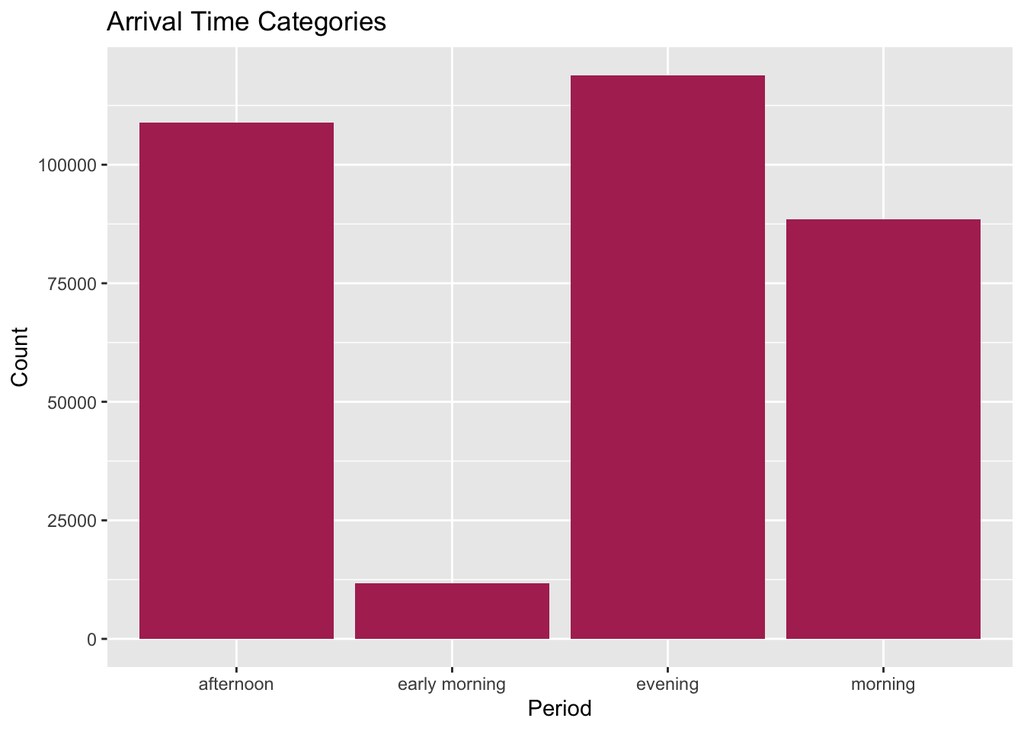

```r
ggplot(flights, aes(arr_cat)) +
  geom_bar(fill = "maroon")+
  labs(title="Arrival Time Categories", x= "Period", y= "Count")
```

```r
mean(flights$dep_cat %in% c("afternoon", "evening") & flights$arr_cat %in% c("early morning", "morning")) * 100
```

```
[1] 3.241146
```

3.24% of the flights were “red eye” flights.

## Question 3

```r
multi_planes <- flights %>%
  filter(!is.na(tailnum), !is.na(carrier)) %>%
  distinct(tailnum, carrier) %>%
  group_by(tailnum) %>%
  summarise(num_airlines = n(), airlines = paste(unique(carrier), collapse = ", ")) %>%
  filter(num_airlines > 1)

multi_planes
```

```
# A tibble: 17 × 3
   tailnum num_airlines airlines
   <chr>          <int> <chr>
 1 N146PQ             2 9E, EV
 2 N153PQ             2 9E, EV
 3 N176PQ             2 9E, EV
 4 N181PQ             2 9E, EV
 5 N197PQ             2 9E, EV
 6 N200PQ             2 9E, EV
 7 N228PQ             2 9E, EV
 8 N232PQ             2 9E, EV
 9 N933AT             2 FL, DL
10 N935AT             2 FL, DL
11 N977AT             2 FL, DL
12 N978AT             2 FL, DL
13 N979AT             2 FL, DL
14 N981AT             2 FL, DL
15 N989AT             2 FL, DL
16 N990AT             2 FL, DL
17 N994AT             2 FL, DL
```

Above table shows the planes that flew for multiple airlines and the airlines they flew for.

```r
nrow(multi_planes)
```

```
[1] 17
```

There are 17 planes that flew for multiple airlines.

## Question 4

```r
weather <- weather
head(weather, 6)
```

```
# A tibble: 6 × 15
  origin  year month   day  hour  temp  dewp humid wind_dir wind_speed wind_gust
  <chr>  <int> <int> <int> <int> <dbl> <dbl> <dbl>    <dbl>      <dbl>     <dbl>
1 EWR     2013     1     1     1  39.0  26.1  59.4      270      10.4         NA
2 EWR     2013     1     1     2  39.0  27.0  61.6      250       8.06        NA
3 EWR     2013     1     1     3  39.0  28.0  64.4      240      11.5         NA
4 EWR     2013     1     1     4  39.9  28.0  62.2      250      12.7         NA
5 EWR     2013     1     1     5  39.0  28.0  64.4      260      12.7         NA
6 EWR     2013     1     1     6  37.9  28.0  67.2      240      11.5         NA
# ℹ 4 more variables: precip <dbl>, pressure <dbl>, visib <dbl>,
#   time_hour <dttm>
```

```r
airport <- airports
head(airports, 6)
```

```
# A tibble: 6 × 8
  faa   name                             lat   lon   alt    tz dst   tzone
  <chr> <chr>                          <dbl> <dbl> <dbl> <dbl> <chr> <chr>
1 04G   Lansdowne Airport               41.1 -80.6  1044    -5 A     America/Ne…
2 06A   Moton Field Municipal Airport   32.5 -85.7   264    -6 A     America/Ch…
3 06C   Schaumburg Regional             42.0 -88.1   801    -6 A     America/Ch…
4 06N   Randall Airport                 41.4 -74.4   523    -5 A     America/Ne…
5 09J   Jekyll Island Airport           31.1 -81.4    11    -5 A     America/Ne…
6 0A9   Elizabethton Municipal Airport  36.4 -82.2  1593    -5 A     America/Ne…
```

Let’s check to see if the faa column in airport is the same airport code as the one’s in origin

```r
all(weather$origin %in% airports$faa)
```

```
[1] TRUE
```

Missing relationship is that there should be an arrow connecting origin field in weather to faa in airports

## Question 5

```r
weather <- weather %>%
  mutate(weather_id = paste(year, month, day, hour, origin, sep = "_"))

sum(duplicated(weather$weather_id))
```

```
[1] 3
```

```r
weather %>%
  filter(duplicated(weather_id))
```

```
# A tibble: 3 × 16
  origin  year month   day  hour  temp  dewp humid wind_dir wind_speed wind_gust
  <chr>  <int> <int> <int> <int> <dbl> <dbl> <dbl>    <dbl>      <dbl>     <dbl>
1 EWR     2013    11     3     1  50    39.0  65.8      290       5.75        NA
2 JFK     2013    11     3     1  52.0  37.9  58.6      310       6.90        NA
3 LGA     2013    11     3     1  54.0  39.9  58.9      310       8.06        NA
# ℹ 5 more variables: precip <dbl>, pressure <dbl>, visib <dbl>,
#   time_hour <dttm>, weather_id <chr>
```

```r
weather %>%
  count(weather_id) %>%
  filter(n > 1)
```

```
# A tibble: 3 × 2
  weather_id          n
  <chr>           <int>
1 2013_11_3_1_EWR     2
2 2013_11_3_1_JFK     2
3 2013_11_3_1_LGA     2
```

Above shows that there are duplicates for Newark; LaGuardia; JFK airport in NYC on 11/3 at 1am. After a quick google search, that day is the day that switched from daylight saving to standard time. That’s why there is a duplicated record at 1am because there was two 1 am.

```r
flights_weather <- flights %>%
  left_join(weather, by = c("origin","time_hour"))

head(flights_weather, 6)
```

```
# A tibble: 6 × 37
  year.x month.x day.x dep_time sched_dep_time dep_delay arr_time sched_arr_time
   <int>   <int> <int>    <int>          <int>     <dbl>    <int>          <int>
1   2013       1     1      517            515         2      830            819
2   2013       1     1      533            529         4      850            830
3   2013       1     1      542            540         2      923            850
4   2013       1     1      544            545        -1     1004           1022
5   2013       1     1      554            600        -6      812            837
6   2013       1     1      554            558        -4      740            728
# ℹ 29 more variables: arr_delay <dbl>, carrier <chr>, flight <int>,
#   tailnum <chr>, origin <chr>, dest <chr>, air_time <dbl>, distance <dbl>,
#   hour.x <dbl>, minute <dbl>, time_hour <dttm>, dep_hour <dbl>,
#   arr_hour <dbl>, dep_cat <chr>, arr_cat <chr>, year.y <int>, month.y <int>,
#   day.y <int>, hour.y <int>, temp <dbl>, dewp <dbl>, humid <dbl>,
#   wind_dir <dbl>, wind_speed <dbl>, wind_gust <dbl>, precip <dbl>,
#   pressure <dbl>, visib <dbl>, weather_id <chr>
```

## Question 6

Step 2 – check the size of the data

```r
dim(flights_weather)
```

```
[1] 328063     37
```

328063 rows (# of obs) x 37 columns (# of variables)

Step 3 – Examine the variables & their types

```r
str(flights_weather)
```

```
tibble [328,063 × 37] (S3: tbl_df/tbl/data.frame)
 $ year.x        : int [1:328063] 2013 2013 2013 2013 2013 2013 2013 2013 2013 2013 ...
 $ month.x       : int [1:328063] 1 1 1 1 1 1 1 1 1 1 ...
 $ day.x         : int [1:328063] 1 1 1 1 1 1 1 1 1 1 ...
 $ dep_time      : int [1:328063] 517 533 542 544 554 554 555 557 557 558 ...
 $ sched_dep_time: int [1:328063] 515 529 540 545 600 558 600 600 600 600 ...
 $ dep_delay     : num [1:328063] 2 4 2 -1 -6 -4 -5 -3 -3 -2 ...
 $ arr_time      : int [1:328063] 830 850 923 1004 812 740 913 709 838 753 ...
 $ sched_arr_time: int [1:328063] 819 830 850 1022 837 728 854 723 846 745 ...
 $ arr_delay     : num [1:328063] 11 20 33 -18 -25 12 19 -14 -8 8 ...
 $ carrier       : chr [1:328063] "UA" "UA" "AA" "B6" ...
 $ flight        : int [1:328063] 1545 1714 1141 725 461 1696 507 5708 79 301 ...
 $ tailnum       : chr [1:328063] "N14228" "N24211" "N619AA" "N804JB" ...
 $ origin        : chr [1:328063] "EWR" "LGA" "JFK" "JFK" ...
 $ dest          : chr [1:328063] "IAH" "IAH" "MIA" "BQN" ...
```

[output cut: 23 more lines]

```r
summary(flights_weather)
```

```
     year.x        month.x           day.x          dep_time    sched_dep_time
 Min.   :2013   Min.   : 1.000   Min.   : 1.00   Min.   :   1   Min.   : 500
 1st Qu.:2013   1st Qu.: 4.000   1st Qu.: 8.00   1st Qu.: 907   1st Qu.: 905
 Median :2013   Median : 7.000   Median :16.00   Median :1400   Median :1355
 Mean   :2013   Mean   : 6.564   Mean   :15.74   Mean   :1349   Mean   :1340
 3rd Qu.:2013   3rd Qu.:10.000   3rd Qu.:23.00   3rd Qu.:1744   3rd Qu.:1729
 Max.   :2013   Max.   :12.000   Max.   :31.00   Max.   :2400   Max.   :2359

   dep_delay          arr_time    sched_arr_time   arr_delay
 Min.   : -43.00   Min.   :   1   Min.   :   1   Min.   : -86.000
 1st Qu.:  -5.00   1st Qu.:1104   1st Qu.:1122   1st Qu.: -17.000
 Median :  -2.00   Median :1535   Median :1555   Median :  -5.000
 Mean   :  12.58   Mean   :1502   Mean   :1533   Mean   :   6.895
 3rd Qu.:  11.00   3rd Qu.:1940   3rd Qu.:1944   3rd Qu.:  14.000
 Max.   :1301.00   Max.   :2400   Max.   :2359   Max.   :1272.000
                                                 NA's   :717
   carrier              flight       tailnum             origin
 Length:328063      Min.   :   1   Length:328063      Length:328063
 Class :character   1st Qu.: 544   Class :character   Class :character
 Mode  :character   Median :1468   Mode  :character   Mode  :character
                    Mean   :1943
                    3rd Qu.:3413
                    Max.   :8500

     dest              air_time        distance        hour.x
 Length:328063      Min.   : 20.0   Min.   :  80   Min.   : 5.00
 Class :character   1st Qu.: 82.0   1st Qu.: 509   1st Qu.: 9.00
 Mode  :character   Median :129.0   Median : 888   Median :13.00
                    Mean   :150.7   Mean   :1049   Mean   :13.14
                    3rd Qu.:192.0   3rd Qu.:1391   3rd Qu.:17.00
                    Max.   :695.0   Max.   :4983   Max.   :23.00
                    NA's   :717
     minute        time_hour                      dep_hour        arr_hour
 Min.   : 0.00   Min.   :2013-01-01 05:00:00   Min.   : 0.00   Min.   : 0.00
 1st Qu.: 8.00   1st Qu.:2013-04-05 06:00:00   1st Qu.: 9.00   1st Qu.:11.00
 Median :29.00   Median :2013-07-04 09:00:00   Median :14.00   Median :15.00
 Mean   :26.24   Mean   :2013-07-03 17:28:06   Mean   :13.17   Mean   :14.73
 3rd Qu.:44.00   3rd Qu.:2013-10-01 17:00:00   3rd Qu.:17.00   3rd Qu.:19.00
 Max.   :59.00   Max.   :2013-12-31 23:00:00   Max.   :24.00   Max.   :24.00

```

[output cut: 17 more lines]

```
 Min.   : 12.74   Min.   :  0.0   Min.   : 0.000   Min.   :16.11
 1st Qu.: 43.74   1st Qu.:130.0   1st Qu.: 6.905   1st Qu.:20.71
 Median : 57.22   Median :220.0   Median :10.357   Median :24.17
 Mean   : 59.22   Mean   :201.9   Mean   :11.061   Mean   :25.15
 3rd Qu.: 74.67   3rd Qu.:290.0   3rd Qu.:14.960   3rd Qu.:27.62
 Max.   :100.00   Max.   :360.0   Max.   :42.579   Max.   :66.75
 NA's   :1545     NA's   :9595    NA's   :1606     NA's   :250461
     precip           pressure          visib         weather_id
 Min.   :0.00000   Min.   : 983.8   Min.   : 0.000   Length:328063
 1st Qu.:0.00000   1st Qu.:1012.9   1st Qu.:10.000   Class :character
 Median :0.00000   Median :1017.6   Median :10.000   Mode  :character
 Mean   :0.00422   Mean   :1017.9   Mean   : 9.289
 3rd Qu.:0.00000   3rd Qu.:1022.9   3rd Qu.:10.000
 Max.   :1.21000   Max.   :1042.1   Max.   :10.000
 NA's   :1528      NA's   :36224    NA's   :1528
```

year variable shows that all data is from 2013

Variables that will be relevant: dep_delay / arr_delay / temp / wind_speed / visib / precip

Step 4 – look at the top & bottom of the data

```r
head(flights_weather)
```

```
# A tibble: 6 × 37
  year.x month.x day.x dep_time sched_dep_time dep_delay arr_time sched_arr_time
   <int>   <int> <int>    <int>          <int>     <dbl>    <int>          <int>
1   2013       1     1      517            515         2      830            819
2   2013       1     1      533            529         4      850            830
3   2013       1     1      542            540         2      923            850
4   2013       1     1      544            545        -1     1004           1022
5   2013       1     1      554            600        -6      812            837
6   2013       1     1      554            558        -4      740            728
# ℹ 29 more variables: arr_delay <dbl>, carrier <chr>, flight <int>,
#   tailnum <chr>, origin <chr>, dest <chr>, air_time <dbl>, distance <dbl>,
#   hour.x <dbl>, minute <dbl>, time_hour <dttm>, dep_hour <dbl>,
#   arr_hour <dbl>, dep_cat <chr>, arr_cat <chr>, year.y <int>, month.y <int>,
#   day.y <int>, hour.y <int>, temp <dbl>, dewp <dbl>, humid <dbl>,
#   wind_dir <dbl>, wind_speed <dbl>, wind_gust <dbl>, precip <dbl>,
#   pressure <dbl>, visib <dbl>, weather_id <chr>
```

```r
tail(flights_weather)
```

```
# A tibble: 6 × 37
  year.x month.x day.x dep_time sched_dep_time dep_delay arr_time sched_arr_time
   <int>   <int> <int>    <int>          <int>     <dbl>    <int>          <int>
1   2013       9    30     2237           2245        -8     2345           2353
2   2013       9    30     2240           2245        -5     2334           2351
3   2013       9    30     2240           2250       -10     2347              7
4   2013       9    30     2241           2246        -5     2345              1
5   2013       9    30     2307           2255        12     2359           2358
6   2013       9    30     2349           2359       -10      325            350
# ℹ 29 more variables: arr_delay <dbl>, carrier <chr>, flight <int>,
#   tailnum <chr>, origin <chr>, dest <chr>, air_time <dbl>, distance <dbl>,
#   hour.x <dbl>, minute <dbl>, time_hour <dttm>, dep_hour <dbl>,
#   arr_hour <dbl>, dep_cat <chr>, arr_cat <chr>, year.y <int>, month.y <int>,
#   day.y <int>, hour.y <int>, temp <dbl>, dewp <dbl>, humid <dbl>,
#   wind_dir <dbl>, wind_speed <dbl>, wind_gust <dbl>, precip <dbl>,
#   pressure <dbl>, visib <dbl>, weather_id <chr>
```

Step 5 – visualise distribution of key variables

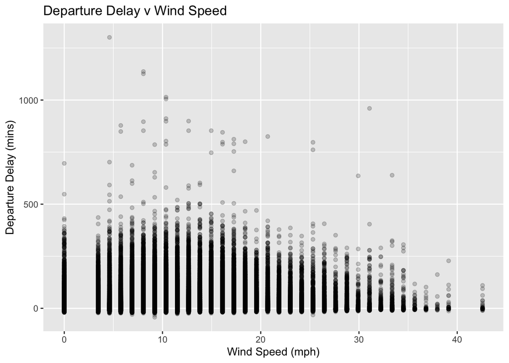

```r
library(ggplot2)

ggplot(flights_weather, aes(x= wind_speed, y= dep_delay)) +
  geom_point(alpha = 0.2)+
  labs(title= "Departure Delay v Wind Speed",
       x="Wind Speed (mph)",
       y="Departure Delay (mins)")
```

Quite a few delays happened when the wind speed is at 0, also see a decrease in delay as wind speed increases, which makes sense because at a certain point it would be too risky to take off

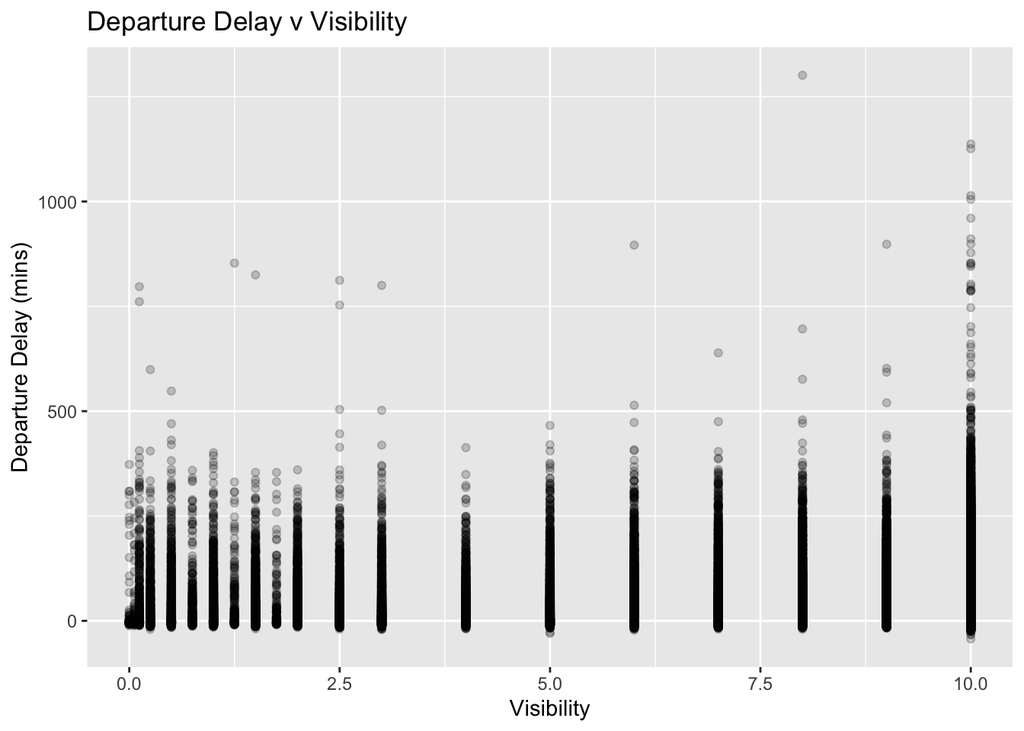

```r
ggplot(flights_weather, aes(x= visib, y= dep_delay)) +
  geom_point(alpha = 0.2)+
  labs(title= "Departure Delay v Visibility",
       x="Visibility",
       y="Departure Delay (mins)")
```

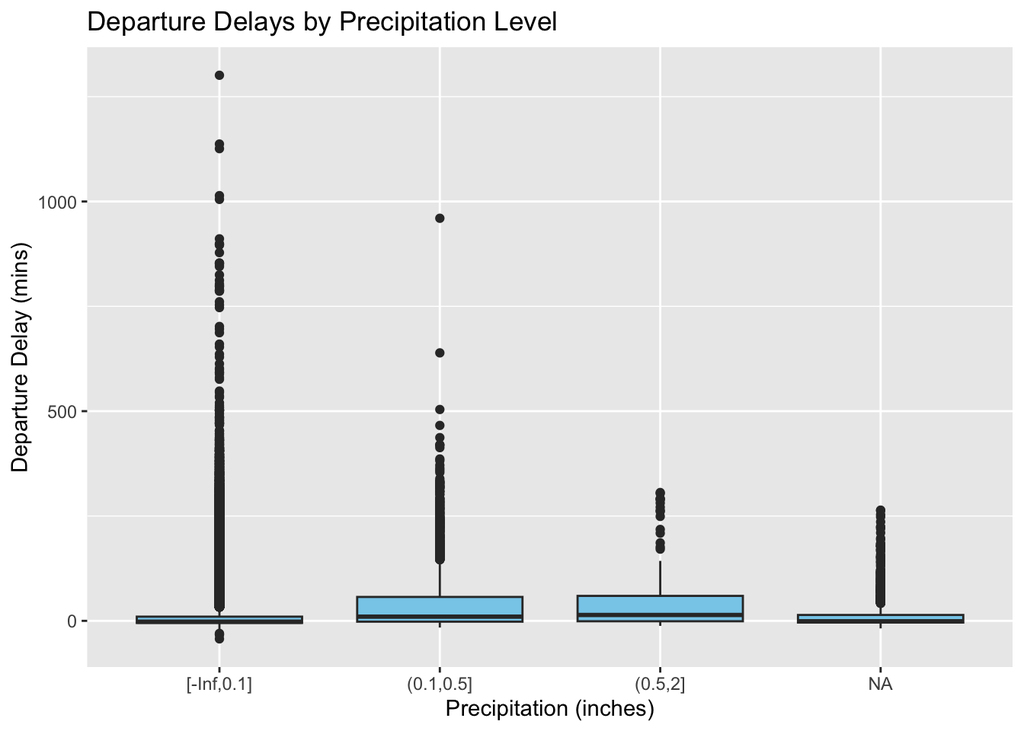

```r
ggplot(flights_weather, aes(x = cut(precip, breaks= c(-Inf, 0.1, 0.5, 2, 10), include.lowest = TRUE), y = dep_delay)) +
  geom_boxplot(fill = "skyblue") +
  labs(title= "Departure Delays by Precipitation Level",
       x="Precipitation (inches)",
       y="Departure Delay (mins)")
```

Appears to have more delays (higher median) for higher precipitation

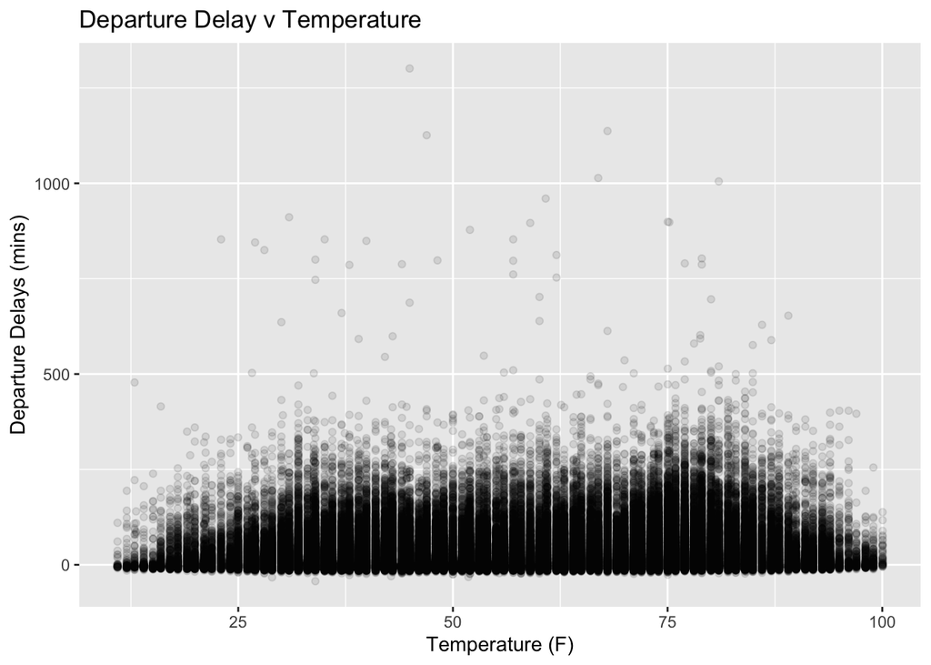

```r
ggplot(flights_weather, aes(x= temp, y= dep_delay)) +
  geom_point(alpha = 0.1) +
  labs(title="Departure Delay v Temperature",
       x= "Temperature (F)",
       y= "Departure Delays (mins)")
```

Appears to be pretty consistent, no particular trend observed yet

## Question 7

Average departure delay

```r
avg_delay <- flights_weather %>%
  group_by(year.x, month.x, day.x) %>%
  summarise(avg_dep_delay = mean(dep_delay, na.rm=TRUE)) %>%
  arrange(desc(avg_dep_delay))
head(avg_delay, 6)
```

```
# A tibble: 6 × 4
# Groups:   year.x, month.x [5]
  year.x month.x day.x avg_dep_delay
   <int>   <int> <int>         <dbl>
1   2013       3     8          83.6
2   2013       7     1          56.4
3   2013       9     2          53.1
4   2013      12     5          52.4
5   2013       7    10          51.7
6   2013       5    23          50.8
```

3/8/2013 has the worst delay of an average departure delay of 83.65 mins.

Average departure delay by origin

```r
avg_delay_orig <- flights_weather %>%
  group_by(origin, year.x, month.x, day.x) %>%
  summarise(avg_dep_delay_origin= mean(dep_delay, na.rm=TRUE)) %>%
  arrange(desc(avg_dep_delay_origin))
head(avg_delay_orig, 6)
```

```
# A tibble: 6 × 5
# Groups:   origin, year.x, month.x [6]
  origin year.x month.x day.x avg_dep_delay_origin
  <chr>   <int>   <int> <int>                <dbl>
1 LGA      2013       3     8                106.
2 EWR      2013       3     8                 97.8
3 LGA      2013       9     2                 80.5
4 LGA      2013      12     5                 75.2
5 LGA      2013       7     1                 62.9
6 EWR      2013      12     5                 61.2
```

Average departure delay by hour and origin

```r
avg_delay_hour_orig <- flights_weather %>%
  group_by(origin, year.x, month.x, day.x, dep_hour) %>%
  summarise(avg_dep_delay_hour= mean(dep_delay, na.rm = TRUE), .groups = "drop") %>%
  arrange(desc(avg_dep_delay_hour))

head(avg_delay_hour_orig, 6)
```

```
# A tibble: 6 × 6
  origin year.x month.x day.x dep_hour avg_dep_delay_hour
  <chr>   <int>   <int> <int>    <dbl>              <dbl>
1 LGA      2013       3    17       23               911
2 LGA      2013       2    19       23               788
3 LGA      2013       7    22       22               542.
4 JFK      2013      12    17        3               503
5 LGA      2013       7    26       23               483
6 LGA      2013       5    23        1               475
```

LGA had the worst single hour for delay and it was on 3/17/2013 at 23h (11pm)

## Question 8

```r
avg_delay_dest <- flights %>%
  group_by(dest) %>%
  summarise(avg_dep_delay= mean(dep_delay, na.rm = TRUE), n_flights = n(), .groups = "drop")

airports_delay <- airports %>%
  left_join(avg_delay_dest, by = c("faa" = "dest"))
```

```r
library(leaflet)

pal <- colorNumeric("YlOrRd", domain = airports_delay$avg_dep_delay)

airports_delay %>%
  filter(!is.na(avg_dep_delay)) %>%
  leaflet() %>%
  addTiles() %>%
  addCircleMarkers(
    lng = ~lon, lat = ~lat,
    radius= 6,
    color= ~pal(avg_dep_delay),
    fillOpacity= 0.8,
    stroke= FALSE,
    popup= ~paste0(
      "<b>", name, " (", faa, ")</b><br>",
      "Avg dep delay: ", round(avg_dep_delay, 1), " min<br>",
      "Flights: ", n_flights
    )
  ) %>%
  addLegend(
    "bottomright",
    pal= pal,
    values= ~avg_dep_delay,
    title= "Avg Departure Delay (min)"
  )
```

[interactive chart not shown]

## Question 9

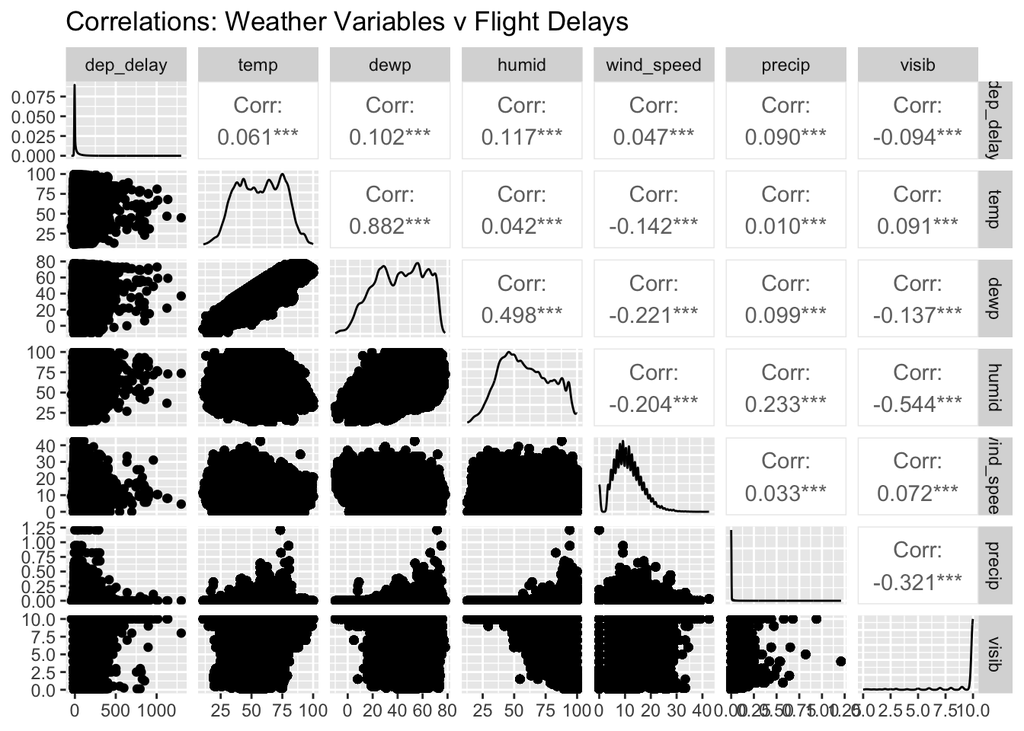

```r
library(GGally)
flights_weather %>%
  select(dep_delay,temp, dewp,humid, wind_speed,precip, visib) %>%
  drop_na() %>%
  ggpairs(title = "Correlations: Weather Variables v Flight Delays")
```

All weather phenomena are statistically significant in their correlation with the departure delay. Among the 6, dew point and humid have the strongest correlation (>0.1)

Temperature and wind speed have the weakest correlation, suggesting that overall moist-related phenomena (humidity / rain / dew point) and the visibility that got affected as well affect the delay time the most.

Similar to step 5 in EAD:

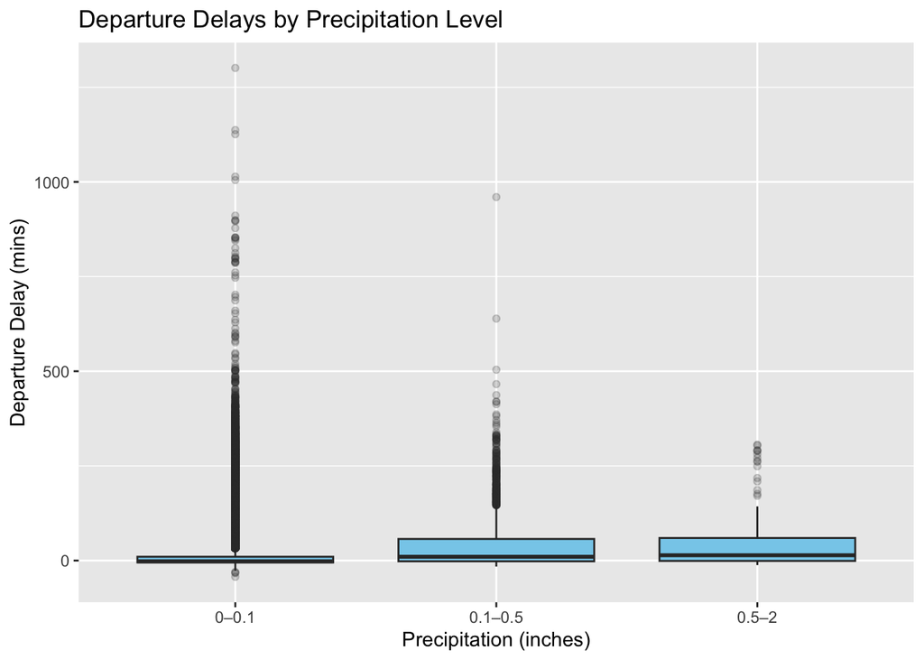

```r
flights_weather %>%
  filter(!is.na(precip)) %>%
  mutate(
    precip_bin = cut(precip,
                     breaks= c(-Inf, 0.1, 0.5, 2, Inf),
                     labels= c("0–0.1", "0.1–0.5", "0.5–2", "2+"),
                     include.lowest = TRUE)
  ) %>%
  ggplot(aes(x= precip_bin, y= dep_delay)) +
  geom_boxplot(fill= "skyblue", outlier.alpha = 0.2) +
  labs(title= "Departure Delays by Precipitation Level",
       x= "Precipitation (inches)",
       y= "Departure Delay (mins)")
```

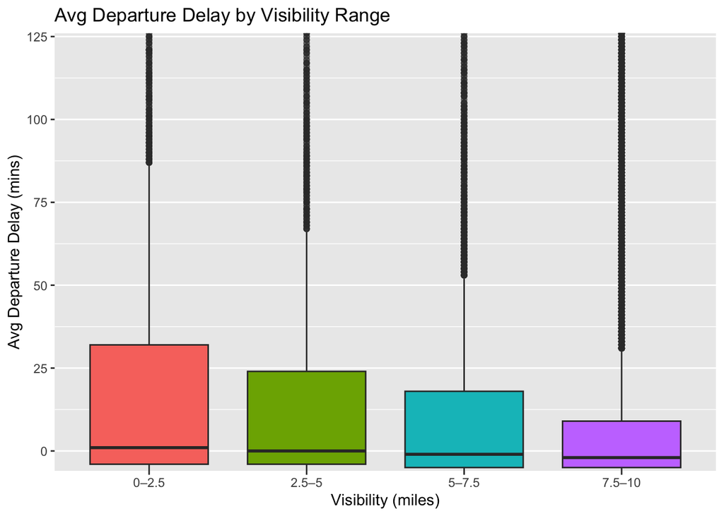

```r
flights_weather %>%
  filter(!is.na(visib)) %>%
  mutate(visib_group= cut(
    visib,
    breaks= c(0, 2.5, 5, 7.5, 10),
    labels= c("0–2.5", "2.5–5", "5–7.5", "7.5–10"),
    include.lowest = TRUE
  )) %>%
  ggplot(aes(x = visib_group, y = dep_delay, fill = visib_group)) +
  geom_boxplot(outlier.alpha = 0.2, show.legend = FALSE) +
  coord_cartesian(ylim = c(0, 120)) + ##hide outliers to better visualise
  labs(
    title= "Avg Departure Delay by Visibility Range",
    x= "Visibility (miles)",
    y= "Avg Departure Delay (mins)"
  )
```

The lower the visibility and higher the delay with a larger range.

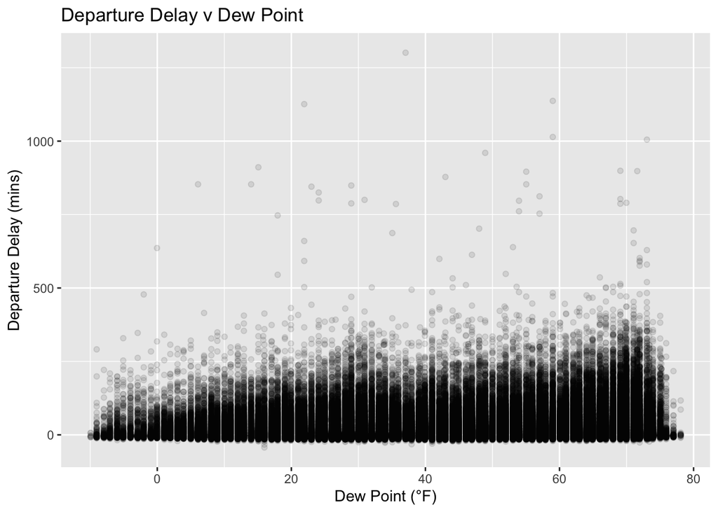

```r
flights_weather %>%
  filter(!is.na(dewp)) %>%
  ggplot(aes(x= dewp, y= dep_delay)) +
  geom_point(alpha= 0.1) +
  labs(title= "Departure Delay v Dew Point",
       x= "Dew Point (°F)",
       y= "Departure Delay (mins)")
```

There is an upward trend in departure delay as dew point increases

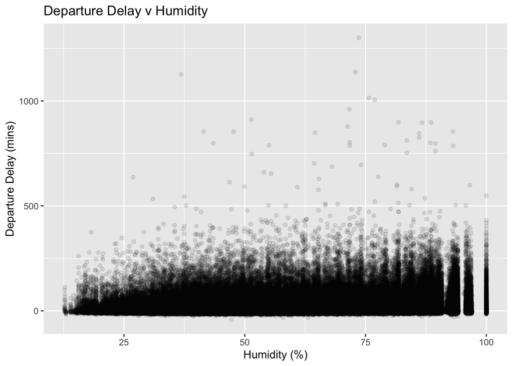

```r
flights_weather %>%
  filter(!is.na(humid)) %>%
  ggplot(aes(x= humid, y= dep_delay)) +
  geom_point(alpha= 0.1) +
  labs(title= "Departure Delay v Humidity",
       x= "Humidity (%)",
       y= "Departure Delay (mins)")
```

Similar trend observed with humidity, departure delay increases as humidity increases.

Overall, all the graphs supported the correlation analysis, that the moist-related phenomena have the strongest impact on the delay time.